# Multiple logistic regression on Heart Disease(CAD)

Zackary Petrasek

September 29th, 2026

# 1 Introduction

According to the CDC, Coronary Artery Disease (CAD) affects 5% of Americans, and around 2% of people with CAD die from it every year. Being able to successfully test people to find this disease can be very important to make sure people get the proper treatment. It is important to note before going into the data set that the population is very specifically people who are already getting tested for CAD, this means that the interpretations are NOT for the general population.

# 2 Data Source

The heart disease data set in this case study contains 920 observations on 16 variables(2 will be removed before exploratory analysis so 14 remaining variables). The data set is originates from the UCI machine learning data repository, gathered by Detrano et al. (1989). However, I accessed the data from kaggle (https://www.kaggle.com/datasets/redwankarimsony/heart-disease-data?resource=download), as the data was not all processed in the UCI data repository. The data looks specifically at the Cleveland data as it has the least amount of observations with missing values. If we were to look at all four sites from the original data set, we would likely have to drop some variables known to be clinically important, as other sites did not record values for these variables. Due to this we will be left with 304 observations, which is still enough.

There are 14 variables in the data set.

1. **age**: Age in years(discrete, numeric)
2. **sex**: Male or Female (binary, categorical)
3. **cp**: Chest pain type, typical angina, atypical angina, non-anginal, or asymptomatic (4-level, categorical)
4. **bp**: Resting systolic blood pressure (discrete, numeric, in mmHg)
5. **chol**: Serum cholesterol (discrete, numeric, in mg/dl)
6. **fbs**: Fasting blood sugar, True if >120 mg/dl, False if not (binary, categorical)
7. **ecg**: Resting electrocardiograph results, showing probable or definite left ventricular hypertrophy(by Estes’ criteria), having ST-T wave abnormality(T wave inversions and/or ST elevation or depression greater than .05 mV), or normal. (Three-level, categorical)
8. **maxbpm**: Maximum heart rate (discrete, numeric, BpM)
9. **exang**: Exercise induced angina, true if yes, false if no (binary, categorical)
10. **oldpeak**: ST depression induced by exercise relative to rest (continuous, numeric, mm)
11. **slope**: Slope of the peak exercise ST segment, downslopping, flat, or upsloping. (Three-level, categorical)
12. **ca**: Number of major vessels colored by fluorosopy, 0, 1, 2, 3. (discrete, numeric)
13. **thal**: Thalassemia status, normal, fixed defect, or reversible defect.(Three-level, categorical)
14. **CAD**: Testing variable (5-level categorical, 0 for no CAD 1-4 for increasing stages of CAD, will turn into binary response variable, with 0 for no CAD, and 1 for any stage of CAD)

The following code loads the heart disease data set, changes characters to factors, and assesses for missingness.

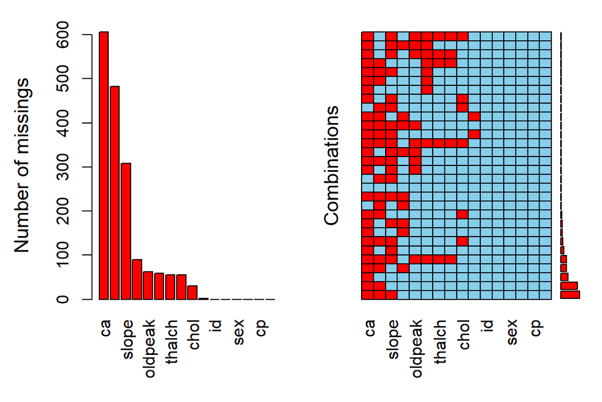

Misingness graphs

```
 Variables sorted by number of missings:
 Variable Count
       ca   606
     thal   483
    slope   308
      fbs    90
  oldpeak    62
 trestbps    59
   thalch    55
    exang    55
     chol    30
  restecg     2
       id     0
      age     0
      sex     0
  dataset     0
       cp     0
      num     0
```

```r
#Read in data set
url <- "https://raw.githubusercontent.com/ZackaryPetrasek/STA321/main/homeworks/hw4/heart.csv"
heart <- read_csv(url)
#Look at missingness in other locations
others <- heart[heart$dataset!= "Cleveland", ]
aggr(others, numbers = TRUE, prop = FALSE, sortVar = TRUE)
```

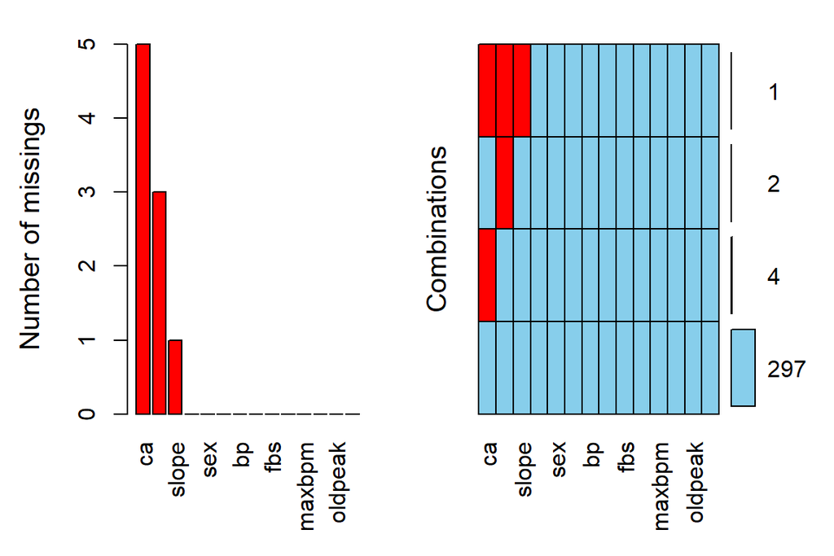

Misingness graphs

```
 Variables sorted by number of missings:
 Variable Count
       ca     5
     thal     3
    slope     1
      age     0
      sex     0
       cp     0
       bp     0
     chol     0
      fbs     0
      ecg     0
   maxbpm     0
    exang     0
  oldpeak     0
      CAD     0
```

```r
#Remove id and observations at sites besides cleveland, then remove the location variable
heart$id <- NULL
heart <- heart[heart$dataset=="Cleveland", ]
heart$dataset <- NULL

#Rename variables to make them easier to weave into thr narrative
names(heart)[c(4,7,8,14)] <- c("bp", "ecg", "maxbpm", "CAD")

#Turn CAD into binary predictory variable
heart <- heart %>% mutate(CAD = if_else(CAD>0, 1, 0))

#Change character values to factors
heart <- heart %>% mutate(across(where(is.character), as.factor))

#Look at missingness in the data
aggr(heart, numbers = TRUE, prop = FALSE, sortVar = TRUE)
```

```r
#remove observations with missing values
heart <- heart[complete.cases(heart), ]
```

As you can see in the first missingness chart, nearly every single value for ca is missing for all of the locations outside of Cleveland, and there are lots of other missing values for other variables, so we will stick with just the Cleveland data. There are 7 observations with missing values in our data set. As we still have more than 15 observations per predictor variable, we can simply remove these observations without worrying about losing too much data. After removing these observations we are still left with 297 observations with 14 variables.

# 3 Research Questions

The research question of this assignment is: * What factors are linked with testing positive for CAD?

As the response variable is a 1 for people who tested positive and 0 for people who tested negative, increases in the odds of a “success” in the model will indicate a variable that is associated with an increased odds of CAD among those being tested.

While the data does not come from a random sample of the population, so it should not be used to make predictions or assumptions of the general population, it is still important to know what factors are most indicative of CAD when someone is getting tested.

# 4 Exploratory Analysis

In order to make sure the data is ready to be put into a model we first need to do some exploratory analysis. First off we will look at the distribution of the variables to see if any variables need to be transformed at all, and then check for multicollinearity issues in the data.

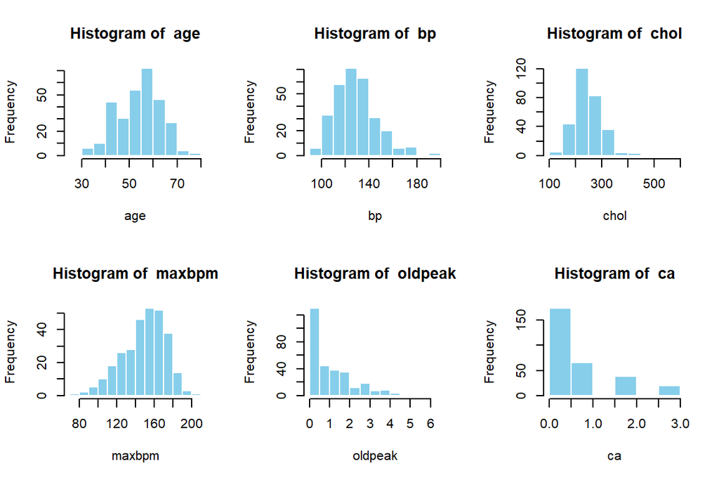

Variable histogram plots

```r
par(mfrow = c(2, 3)) # Arrange plots in a 2x3 grid
hquant <- Filter(is.numeric, heart)
for (i in 1:6) {
  #create histograms fo =r each variable to show distribution patterns
  hist(hquant[[i]], main = paste("Histogram of ", names(hquant)[i]),
  xlab = names(hquant)[i], col = "skyblue", border = "white")
}
```

Ca and oldpeak seem slightly skewed, which is not necessarily a big deal but worth looking into. As ca is already a discrete numeric variables we do not need to group it further, but based on the skewed distribution and clinically an oldpeak value of 1 or more being considered abnormal, we will discretize oldpeak. We will call this variable abnpeak with a value of one or higher being TRUE while a value less than one being FALSE.

```r
#discretize oldpeak by breaking it up into groups
heart$abnpeak <- heart$oldpeak>=1
heart$oldpeak<- NULL
```

We can also do transformation on the blood pressure(bp), cholesterol(chol), age, and maxbpm variables. As of right now a unit increase likely has a very small effect since the increase of a single unit in these variables changes their value much less than a change of a level in a 2-3 level categorical variable. To do this we will change the scale for bp, chol, and maxbpm, to increases of 10 units, and for age change the scale to 5 year units.

```r
#re-scale some numeric variables
   heart <- heart %>% mutate(bp = bp/10, chol = chol/10, maxbpm = maxbpm/10, age = age/5)
```

After looking at the numeric variables it is also important to the categorical variables to check for sparseness.

```r
#look at all categorical variables from the data set, gather their count, and percent of observations, and create chart to look for sparsity in the categorical variables.
heart[sapply(heart, is.factor)] %>%
  pivot_longer(cols = everything(), names_to = "Variable", values_to = "Category") %>%
  count(Variable, Category) %>%
  group_by(Variable) %>%
  mutate(Percentage = round(n / sum(n) * 100, 1)) %>%
  gt(groupname_col = "Variable") %>%
  cols_label( Category = "Category Level", n = "Count", Percentage = "Percentage (%)") %>%
  tab_header(title = "Summary of All Categorical Variables", subtitle = "Combined frequency and percentage breakdown")
```

Summary of All Categorical Variables

Combined frequency and percentage breakdown

| Category Level | Count | Percentage (%) |
| --- | --- | --- |
| cp |  |  |
| asymptomatic | 142 | 47.8 |
| atypical angina | 49 | 16.5 |
| non-anginal | 83 | 27.9 |
| typical angina | 23 | 7.7 |
| ecg |  |  |
| lv hypertrophy | 146 | 49.2 |
| normal | 147 | 49.5 |
| st-t abnormality | 4 | 1.3 |
| sex |  |  |
| Female | 96 | 32.3 |
| Male | 201 | 67.7 |
| slope |  |  |
| downsloping | 21 | 7.1 |
| flat | 137 | 46.1 |
| upsloping | 139 | 46.8 |
| thal |  |  |
| normal | 164 | 55.2 |
| fixed defect | 18 | 6.1 |
| reversable defect | 115 | 38.7 |

We can see that there are only 4 observations with st-t abnormality, this is incredibly sparse and any interpretation on this level of the variable would not have much meaning. Instead, we could instead re-group ecg to have a normal level and an abnormality level, grouping lv hypertrophy and st-t abnormality together. At the same time we should consider re-leveling some of our other categorical variables. At the moment thal and slope have sparse levels as their base level, while they are not sparse enough to require re-grouping, it would be a good idea to change the base level of these variables.

```r
#Regroup ecg
heart <- heart %>% mutate(ecg = if_else(ecg=="normal", "normal", "abnormal"))
heart <- heart %>% mutate(across(where(is.character), as.factor))
#Re-level thal, slope, ecg
   heart$thal  <- relevel(heart$thal,  ref = "normal")
   heart$slope <- relevel(heart$slope, ref = "flat")
   heart$ecg <- relevel(heart$ecg, ref = "normal")
```

Next we need to check for any multicollinearity issues, and we can do this using the VIF function.

```r
#use vif function to check for multicollinearity issues
model <- lm(CAD ~ ., data=heart)
vif(model)
```

```
            GVIF Df GVIF^(1/(2*Df))
age     1.501831  1        1.225492
sex     1.326481  1        1.151730
cp      1.684775  3        1.090830
bp      1.211720  1        1.100782
chol    1.153271  1        1.073905
fbs     1.111851  1        1.054443
ecg     1.115256  1        1.056057
maxbpm  1.748001  1        1.322120
exang   1.431236  1        1.196343
slope   1.743687  2        1.149125
ca      1.321801  1        1.149696
thal    1.653561  2        1.133979
abnpeak 1.584886  1        1.258923
```

As we can see using the VIF function, all of the GVIF values are under 2, which is good as VIF values above 4 are when we start to think about multicollinearity issues. So we do not have to worry about multicollinearity in this data set.

The response variable, `CAD`, is a binary categorical variable. In the data set of 297 subjects, 137 (0.4612795%) were diagnosed with CAD. From a modeling perspective, this distribution does not indicate a class imbalance that would bias the results.

# 5 Building Multiple Logistic Regression Model

Based on the exploratory analysis above, the one discretized variables will be used in the following model building. We will start with a full model and then use automatic model selection to find the best logistic model to represent our data.

## 5.1 Full model

The response variable CAD is a binary factor. The model thus estimates the probability of the event, P(CAD = 1, “positive” test result). We start with the full model including all predictor variables gathered which are thought to have an association with CAD. The logistic regression model was fitted as follows:

```r
#create full model
full.model = glm(CAD ~.,
          family = binomial(link = "logit"),
          data = heart)
#create summary output for full model
pander(summary(full.model)$coef,
      caption="Summary of inferential statistics of the full model")
```

Summary of inferential statistics of the full model

|  | Estimate | Std. Error | z value | Pr(>\|z\|) |
| --- | --- | --- | --- | --- |
| **(Intercept)** | -2.863 | 2.656 | -1.078 | 0.2811 |
| **age** | -0.08041 | 0.1232 | -0.6528 | 0.5139 |
| **sexMale** | 1.579 | 0.5236 | 3.015 | 0.002572 |
| **cpatypical angina** | -0.8818 | 0.562 | -1.569 | 0.1167 |
| **cpnon-anginal** | -1.794 | 0.4931 | -3.637 | 0.0002759 |
| **cptypical angina** | -2.045 | 0.6557 | -3.119 | 0.001814 |
| **bp** | 0.2645 | 0.1116 | 2.37 | 0.01778 |
| **chol** | 0.04096 | 0.04018 | 1.019 | 0.308 |
| **fbsTRUE** | -0.7126 | 0.6016 | -1.185 | 0.2362 |
| **ecgabnormal** | 0.5299 | 0.3849 | 1.377 | 0.1686 |
| **maxbpm** | -0.175 | 0.1112 | -1.573 | 0.1156 |
| **exangTRUE** | 0.729 | 0.4387 | 1.662 | 0.0966 |
| **slopedownsloping** | -0.4058 | 0.7814 | -0.5193 | 0.6035 |
| **slopeupsloping** | -1.231 | 0.4655 | -2.645 | 0.00816 |
| **ca** | 1.368 | 0.2778 | 4.926 | 8.41e-07 |
| **thalfixed defect** | 0.06409 | 0.7834 | 0.08181 | 0.9348 |
| **thalreversable defect** | 1.417 | 0.4242 | 3.34 | 0.0008367 |
| **abnpeakTRUE** | 0.5578 | 0.4326 | 1.289 | 0.1973 |

## 5.2 Manual Model

Next it is important to look at a reduced model, to set a lower bound for the model, keeping in variables clinically known to be the most associated with CAD. As a result we will manually select the variables ca(number of vessels colored by fluoroscopy), cp(chest pain type), and thal(Thalassemia status). The reason these are tied so closely with CAD is because they all show what kind of heart issues a person is having, and how severe those current issues are.

```r
#create reduce model
reduced.model = glm(CAD ~ ca + cp + thal,
          family = binomial(link = "logit"),
          data = heart)
# create summary output for reduced model
pander(summary(reduced.model)$coef,
      caption="Summary of inferential statistics of the reduced model")
```

Summary of inferential statistics of the reduced model

|  | Estimate | Std. Error | z value | Pr(>\|z\|) |
| --- | --- | --- | --- | --- |
| **(Intercept)** | -0.8539 | 0.2975 | -2.87 | 0.004099 |
| **ca** | 1.168 | 0.2134 | 5.474 | 4.401e-08 |
| **cpatypical angina** | -1.82 | 0.4847 | -3.755 | 0.0001731 |
| **cpnon-anginal** | -2.071 | 0.412 | -5.027 | 4.973e-07 |
| **cptypical angina** | -1.596 | 0.5379 | -2.967 | 0.003003 |
| **thalfixed defect** | 1.366 | 0.6421 | 2.127 | 0.03342 |
| **thalreversable defect** | 2.188 | 0.3509 | 6.236 | 4.496e-10 |

## 5.3 Automatic model

The last model we are going to look at will be a model in between our reduced and full model. The reduced model may content too little and insufficient information, while out full model may be overfitting the model(being too specific to out data and not a good model to generalize takeaways). To try and find a middle ground between these two issues we will use automatic variable selection to get strong-performing model that adds our variables in the reduced models with other important variables from the data.

```r
# use step-wise selection using AIC to find most impactful variables
final.model.forward = stepAIC(reduced.model,
                      scope = list(lower=formula(reduced.model),upper=formula(full.model)),
                      direction = "forward",   # forward selection
                      trace = 0   # do not show the details
                      )
#create summary output for stepwise selected model
pander(summary(final.model.forward)$coef,
      caption="Summary of inferential statistics of the step-wise model")
```

Summary of inferential statistics of the step-wise model

|  | Estimate | Std. Error | z value | Pr(>\|z\|) |
| --- | --- | --- | --- | --- |
| **(Intercept)** | -1.973 | 1.951 | -1.011 | 0.312 |
| **ca** | 1.285 | 0.2503 | 5.134 | 2.837e-07 |
| **cpatypical angina** | -1.021 | 0.5466 | -1.867 | 0.06188 |
| **cpnon-anginal** | -1.92 | 0.4793 | -4.005 | 6.197e-05 |
| **cptypical angina** | -2.016 | 0.6458 | -3.121 | 0.001803 |
| **thalfixed defect** | -0.1684 | 0.7491 | -0.2248 | 0.8221 |
| **thalreversable defect** | 1.391 | 0.4117 | 3.378 | 0.0007295 |
| **slopedownsloping** | -0.3473 | 0.7339 | -0.4733 | 0.636 |
| **slopeupsloping** | -1.462 | 0.4419 | -3.309 | 0.0009346 |
| **sexMale** | 1.494 | 0.4916 | 3.039 | 0.00237 |
| **bp** | 0.2418 | 0.1014 | 2.385 | 0.0171 |
| **exangTRUE** | 0.7368 | 0.4265 | 1.728 | 0.08406 |
| **maxbpm** | -0.16 | 0.1 | -1.6 | 0.1097 |

## 5.4 Model Comparison

```r
#create functions that will gather the goodness of fit measures for all three models
global.measure=function(s.logit){
dev.resid = s.logit$deviance
dev.0.resid = s.logit$null.deviance
aic = s.logit$aic
goodness = cbind(Deviance.residual =dev.resid, Null.Deviance.Residual = dev.0.resid,
      AIC = aic)
goodness
}
# apply these functions to our models and create summary output of goodness of fit models
goodness=rbind(full.model = global.measure(full.model),
      reduced.model=global.measure(reduced.model),
      final.model=global.measure(final.model.forward) )
row.names(goodness) = c("full.model", "reduced.model", "auto.selected.model")
pander(goodness, caption ="Comparison of global goodness-of-fit statistics")
```

Comparison of global goodness-of-fit statistics

|  | Deviance.residual | Null.Deviance.Residual | AIC |
| --- | --- | --- | --- |
| **full.model** | 192.6 | 409.9 | 228.6 |
| **reduced.model** | 237.1 | 409.9 | 251.1 |
| **auto.selected.model** | 199.2 | 409.9 | 225.2 |

The above results shows that

- The **full.model** and the **auto.selected.model** have similar **residual deviance** and *AIC*, which are both much smaller than the *reduced.model*. As smaller values of **residual deviance** and *AIC* are wanted we will not move forward with the *reduced.model*

We next use the likelihood ratio chi-squared test to see whether the the **full.model**, the **auto.selected.model**, and the **manual.model** are significantly different.

First we will compare the **full.model** and the **auto.selected.model**. The chi-square test statistic is defined to be

$$\text{Residual.Deviance}_{\text{auto.selected.model}} -
\text{Residual.Deviance}_{\text{full.model}} = 199.2-192.6 = 6.6.$$

The degrees of freedom is

$$DF = \text{Num of variables in the full.model} - \text{Num of variables
in the auto.selected.model} = 18-13 = 5$$

The p-value of the above likelihood ratio test is given by

$$\text{p-value} = P(\chi^2_5 > 6.6) = 0.2521$$

Since the p-value indicates that the two models are not statistically different, we will select the **auto.selected.model** due to the principal of parsimony.

# 6 Final Model

The general formula of our final model is:

**CAD ~ ca + cp + thal + slope + sex + bp + exang + maxbpm**

To check to make sure the model does not violate any assumptions we can confidently move forward in interpreting the coefficients of the model.

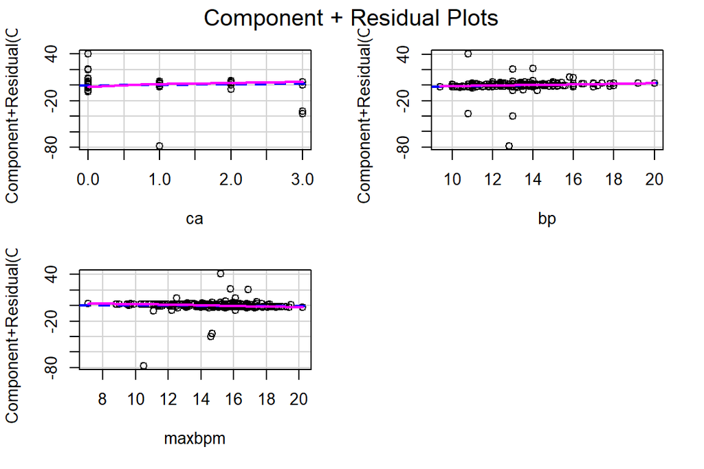

Model residuals for numeric variables

```r
#Check residuals of the variables in final
car::crPlots(final.model.forward, terms = ~ ca + bp + maxbpm)
```

Looking at these charts we do not see any issues, as all of the pink lines remain close to the 0 line, so we can move forward in with our interpretation.

## 6.1 Bootstrapping

In order to add an extra layer of validation to the results we will do some bootstrapping to add a bootstrap confidence interval of our odds ratios to our final model summary.

```r
#setting up a matrix to take in the bootstrapped coefficients
B = 1000

num.p = dim(model.frame(final.model.forward))[2]+4
smpl.n = dim(model.frame(final.model.forward))[1]
coef.mtrx = matrix(rep(0, B*num.p), ncol = num.p)
#running the case bootstrap method by re-sampling from original data set
for (i in 1:B){
  bootc.id = sample(1:smpl.n, smpl.n, replace = TRUE)
  heart.btc = glm(formula(final.model.forward),
          family = binomial(link = "logit"),
          data = heart[bootc.id, ])
  coef.mtrx[i,] = coef(heart.btc)
}
```

After gathering the bootstrap information it is time to make the table including the summary of the final model along side odds ratios with 95% confidence intervals and 95% bootstrap confidence intervals for the odd ratios.

```r
#extract standard summary stats and odds ratios
model.coef.stats = summary(final.model.forward)$coef
odds.ratio = exp(coef(final.model.forward))

# compute 95% CIs for odds ratios
profile_or_ci = exp(confint(final.model.forward))

#compute 95% bootstrap  CIs for odds ratios
boot_or_matrix = exp(coef.mtrx)
boot_ci = apply(boot_or_matrix, 2, quantile, probs = c(0.025, 0.975), na.rm = TRUE)

# create summary output for final model with all CIs
out.stats = cbind(
  model.coef.stats,
  "Odds.Ratio"    = odds.ratio,
  "Odds.Ratio.2.5%"  = profile_or_ci[, 1],
  "Odds.Ratio.97.5%" = profile_or_ci[, 2],
  "Boot.2.5%"     = boot_ci[1, ],
  "Boot.97.5%"    = boot_ci[2, ]
)

# 5. Render nicely with pander
pander(out.stats, caption = "Summary Statistics with Odds Ratios, Profile CIs, and Bootstrap CIs")
```

Summary Statistics with Odds Ratios, Profile CIs, and Bootstrap CIs (continued below)

|  | Estimate | Std. Error | z value | Pr(>\|z\|) |
| --- | --- | --- | --- | --- |
| **(Intercept)** | -1.973 | 1.951 | -1.011 | 0.312 |
| **ca** | 1.285 | 0.2503 | 5.134 | 2.837e-07 |
| **cpatypical angina** | -1.021 | 0.5466 | -1.867 | 0.06188 |
| **cpnon-anginal** | -1.92 | 0.4793 | -4.005 | 6.197e-05 |
| **cptypical angina** | -2.016 | 0.6458 | -3.121 | 0.001803 |
| **thalfixed defect** | -0.1684 | 0.7491 | -0.2248 | 0.8221 |
| **thalreversable defect** | 1.391 | 0.4117 | 3.378 | 0.0007295 |
| **slopedownsloping** | -0.3473 | 0.7339 | -0.4733 | 0.636 |
| **slopeupsloping** | -1.462 | 0.4419 | -3.309 | 0.0009346 |
| **sexMale** | 1.494 | 0.4916 | 3.039 | 0.00237 |
| **bp** | 0.2418 | 0.1014 | 2.385 | 0.0171 |
| **exangTRUE** | 0.7368 | 0.4265 | 1.728 | 0.08406 |
| **maxbpm** | -0.16 | 0.1 | -1.6 | 0.1097 |

Table continues below

|  | Odds.Ratio | Odds.Ratio.2.5% | Odds.Ratio.97.5% |
| --- | --- | --- | --- |
| **(Intercept)** | 0.1391 | 0.002763 | 6.059 |
| **ca** | 3.614 | 2.271 | 6.089 |
| **cpatypical angina** | 0.3604 | 0.1178 | 1.024 |
| **cpnon-anginal** | 0.1467 | 0.0552 | 0.3656 |
| **cptypical angina** | 0.1332 | 0.03498 | 0.4503 |
| **thalfixed defect** | 0.845 | 0.1922 | 3.756 |
| **thalreversable defect** | 4.018 | 1.81 | 9.161 |
| **slopedownsloping** | 0.7066 | 0.1652 | 2.966 |
| **slopeupsloping** | 0.2317 | 0.09492 | 0.5417 |
| **sexMale** | 4.456 | 1.747 | 12.15 |
| **bp** | 1.273 | 1.049 | 1.564 |
| **exangTRUE** | 2.089 | 0.8987 | 4.824 |
| **maxbpm** | 0.8522 | 0.6956 | 1.032 |

|  | Boot.2.5% | Boot.97.5% |
| --- | --- | --- |
| **(Intercept)** | 0.002343 | 3.787 |
| **ca** | 2.101 | 8.808 |
| **cpatypical angina** | 0.08204 | 0.9179 |
| **cpnon-anginal** | 0.03679 | 0.3529 |
| **cptypical angina** | 0.01918 | 0.4795 |
| **thalfixed defect** | 0.1626 | 4.736 |
| **thalreversable defect** | 1.746 | 11.89 |
| **slopedownsloping** | 0.1602 | 2.863 |
| **slopeupsloping** | 0.06939 | 0.5736 |
| **sexMale** | 1.898 | 16.18 |
| **bp** | 1.062 | 1.658 |
| **exangTRUE** | 0.9626 | 4.939 |
| **maxbpm** | 0.6521 | 1.055 |

The bootstrap confidence intervals are similar the to the confidence intervals from out original model, with the bootstrap confidence intervals being wider. In general all of our Odds ratios are withing in the bootstrap confidence intervals which helps validate the model slightly more. In terms of reporting on the meaning of the coefficients when looking at the odds ratio that tells you for every increase of one or one level, of a variable the odds of heart disease gets multiplied by that amount.

What this means for each variable is:

**ca**: OR = 3.614 (95% CI 2.271–6.089); each additional vessel is associated with about 3.6 times the odds, holding other variables constant.

**cp(atypical angina)**: OR = 0.3604 (95% CI 0.1178–1.024); atypical angina is associated with about 0.36 times the odds compared to asymptomatic, holding other variables constant. As 1 is included in the confidence interval this means atypical angina by itself is not significantly shown to affect the odds of testing positive for CAD.

**cp(non-anginal)**: OR = 0.1467 (95% CI 0.0552–0.3656); non-anginal chest pain is associated with about 0.15 times the odds compared to asymptomatic, holding other variables constant.

**cp(typical angina)**: OR = 0.1332 (95% CI 0.03498–0.4503); typical angina is associated with about 0.13 times the odds compared to asymptomatic, holding other variables constant.

**thal(fixed defect)**: OR = 0.845 (95% CI 0.1922–3.756); having fixed defect thalassemia is associated with about 0.85 times the odds compared to no defect, holding other variables constant. As 1 is included in the confidence interval this means fixed defect thalassemia by itself is not significantly shown to affect the odds of testing positive for CAD.

**thal(reversible defect)**: OR = 4.018 (95% CI 1.81–9.161); having reversible defect thalassemia is associated with about 4.018 times the odds compared to no defect, holding other variables constant.

**slope(down-sloping)**: OR = 0.7066 (95% CI 0.1652–2.966); down-sloping ST segment during peak exercise is associated with about 0.7066 times the odds compared to flat slope, holding other variables constant. As 1 is included in the confidence interval this means down-sloping ST segment during peak exercise by itself is not significantly shown to affect the odds of testing positive for CAD.

**slope(up-sloping)**: OR = 0.2317 (95% CI 0.09492–0.5417); up-sloping ST segment during peak exercise is associated with about 0.2317 times the odds compared to flat slope, holding other variables constant.

**sex(Male)**: OR = 4.456 (95% CI 1.747–12.15); being male is associated with about 4.456 times the odds compared to female holding other variables constant.

**bp**: OR = 1.273 (95% CI 1.049–1.564); per 10 mmHg increase in systolic blood pressure is associated with about 1.273 times the odds compared to flat slope, holding other variables constant.

**exang(TRUE)**: OR = 2.089 (95% CI 0.8987–4.824); exercise induced angina is associated with about 2.089 times the odds compared to flat slope, holding other variables constant. As 1 is included in the confidence interval this means exercise induced angina is not significantly shown to affect the odds of testing positive for CAD.

**maxbpm**: OR = 0.8522 (95% CI 0.6956–1.032); per 10 bpm increase in maximum heart rate is associated with about 0.8522 times the odds compared to flat slope, holding other variables constant. As 1 is included in the confidence interval this means maximum heart rate is not significantly shown to affect the odds of testing positive for CAD.

# 7 Conclusion and Discussion

Looking back at our research question “What factors are linked with testing positive for CAD?” We can see that ca(about 3.6x the odds per vessel colored), cp, thal, slope, sex(about 4.5x if male), and bp(about 1.27x the odds per increase of 10 mmHg) are the variables shown to be significantly statistically associated with a positive test for CAD.

This meant that age, chol, fbs, ecg, the discretized oldpeak, maxbpm, and exang were not shown to be statistically significantly associated, despite maxbpm and exang remaining in the final model as their odds ratio confidence intervals included 1.

One surprising result from the assignment was that asymptomatic was the value of chest pain that had the highest odds of a positive CAD test, if we were to generalize this to the population this would mean that any kind of chest pain is actually negatively associated with heart disease. This is a prime example of why we cannot use this model to generalize since chest pain would normally be considered a possible predictor of heart disease, but this data set shows it as the opposite.

Some limitations of the assignment include:

- The data was not a random sample of the population, but instead a sample of those already being tested for CAD so the model can not be generalized.
- Due to the selection bias we can only see association not causation.
- The data is also almost 40 years old

*Slightly small sample size, leads to some wide CIs such as sex(1.7-12) and thal with reservist defects(1.8-9)

The next step for this data is to creative a predictive model for the next assignment.